# ReneWind

#### Problem Statement

ReneWind is a company that will try to maintain the wind turbine renewable energy farm. It needs to keep the mainteannce cost associated with the wind turbine generators to a minimum.So in this scenario we want to maximize the TP so we can correctly find those that will fail. We need to reduce FN as this will cost the company lot of money to replace the generator of the wind turbine.We also should like to reduce FP as this will cost the company inspection costs. Maintenance cost = TP*(Repair cost) + FN*(Replacement cost) + FP*(Inspection cost) where,

Replacement cost = $40,000 Repair cost = $15,000 Inspection cost = $5,000 Here the objective is to reduce the maintenance cost so, we want a metric that could reduce the maintenance cost.

The minimum possible maintenance cost = Actual failures*(Repair cost) = (TP + FN)*(Repair cost) The maintenance cost associated with model = TP*(Repair cost) + FN*(Replacement cost) + FP*(Inspection cost) So, we will try to maximize the ratio of minimum possible maintenance cost and the maintenance cost associated with the model.

```python
# To help with reading and manipulating data
import pandas as pd
import numpy as np

# To help with data visualization
%matplotlib inline
import matplotlib.pyplot as plt
import seaborn as sns

# To be used for missing value imputation
from sklearn.impute import SimpleImputer

# To help with model building
from sklearn.linear_model import LogisticRegression
from sklearn.tree import DecisionTreeClassifier
from sklearn.ensemble import (
    AdaBoostClassifier,
    GradientBoostingClassifier,
    RandomForestClassifier,
    BaggingClassifier,
)
from xgboost import XGBClassifier
# To oversample and undersample data
from imblearn.over_sampling import SMOTE
from imblearn.under_sampling import RandomUnderSampler

# To get different metric scores, and split data
from sklearn import metrics
from sklearn.model_selection import train_test_split, StratifiedKFold, cross_val_score
from sklearn.metrics import (
    f1_score,
    accuracy_score,
    recall_score,
    precision_score,
    confusion_matrix,
    roc_auc_score,
    plot_confusion_matrix,
)

# To be used for data scaling and one hot encoding
from sklearn.preprocessing import StandardScaler, MinMaxScaler, OneHotEncoder

# To oversample and undersample data
from imblearn.over_sampling import SMOTE
from imblearn.under_sampling import RandomUnderSampler

# To be used for tuning the model
from sklearn.model_selection import GridSearchCV, RandomizedSearchCV

# To be used for creating pipelines and personalizing them
from sklearn.pipeline import Pipeline
from sklearn.compose import ColumnTransformer

# To define maximum number of columns to be displayed in a dataframe
pd.set_option("display.max_columns", None)

# To supress scientific notations for a dataframe
pd.set_option("display.float_format", lambda x: "%.3f" % x)

# To supress warnings
import warnings

warnings.filterwarnings("ignore")
```

### Load Data

```python
data = pd.read_csv("Train.csv")
data.head()
```

|  | V1 | V2 | V3 | V4 | V5 | V6 | V7 | V8 | V9 | V10 | V11 | V12 | V13 | V14 | V15 | V16 | V17 | V18 | V19 | V20 | V21 | V22 | V23 | V24 | V25 | V26 | V27 | V28 | V29 | … |
| --- | --- | --- | --- | --- | --- | --- | --- | --- | --- | --- | --- | --- | --- | --- | --- | --- | --- | --- | --- | --- | --- | --- | --- | --- | --- | --- | --- | --- | --- | --- |
| 0 | -4.465 | -4.679 | 3.102 | 0.506 | -0.221 | -2.033 | -2.911 | 0.051 | -1.522 | 3.762 | -5.715 | 0.736 | 0.981 | 1.418 | -3.376 | -3.047 | 0.306 | 2.914 | 2.270 | 4.395 | -2.388 | 0.646 | -1.191 | 3.133 | 0.665 | -2.511 | -0.037 | 0.726 | -3.982 | … |
| 1 | -2.910 | -2.569 | 4.109 | 1.317 | -1.621 | -3.827 | -1.617 | 0.669 | 0.387 | 0.854 | -6.353 | 4.272 | 3.162 | 0.258 | -3.547 | -4.285 | 2.897 | 1.508 | 3.668 | 7.124 | -4.096 | 1.015 | -0.970 | -0.968 | 2.064 | -1.646 | 0.427 | 0.735 | -4.470 | … |
| 2 | 4.284 | 5.105 | 6.092 | 2.640 | -1.041 | 1.308 | -1.876 | -9.582 | 3.470 | 0.763 | -2.573 | -3.350 | -0.595 | -5.247 | -4.310 | -16.232 | -1.000 | 2.318 | 5.942 | -3.858 | -11.599 | 4.021 | -6.281 | 4.633 | 0.930 | 6.280 | 0.851 | 0.269 | -2.206 | … |
| 3 | 3.366 | 3.653 | 0.910 | -1.368 | 0.332 | 2.359 | 0.733 | -4.332 | 0.566 | -0.101 | 1.914 | -0.951 | -1.255 | -2.707 | 0.193 | -4.769 | -2.205 | 0.908 | 0.757 | -5.834 | -3.065 | 1.597 | -1.757 | 1.766 | -0.267 | 3.625 | 1.500 | -0.586 | 0.783 | … |
| 4 | -3.832 | -5.824 | 0.634 | -2.419 | -1.774 | 1.017 | -2.099 | -3.173 | -2.082 | 5.393 | -0.771 | 1.107 | 1.144 | 0.943 | -3.164 | -4.248 | -4.039 | 3.689 | 3.311 | 1.059 | -2.143 | 1.650 | -1.661 | 1.680 | -0.451 | -4.551 | 3.739 | 1.134 | -2.034 | … |

```python
data.tail()
```

|  | V1 | V2 | V3 | V4 | V5 | V6 | V7 | V8 | V9 | V10 | V11 | V12 | V13 | V14 | V15 | V16 | V17 | V18 | V19 | V20 | V21 | V22 | V23 | V24 | V25 | V26 | V27 | V28 | V29 | … |
| --- | --- | --- | --- | --- | --- | --- | --- | --- | --- | --- | --- | --- | --- | --- | --- | --- | --- | --- | --- | --- | --- | --- | --- | --- | --- | --- | --- | --- | --- | --- |
| 39995 | -3.897 | -3.942 | -0.351 | -2.417 | 1.108 | -1.528 | -3.520 | 2.055 | -0.234 | -0.358 | -3.782 | 2.180 | 6.112 | 1.985 | -8.330 | -1.639 | -0.915 | 5.672 | -3.924 | 2.133 | -4.502 | 2.777 | 5.728 | 1.620 | -1.700 | -0.042 | -2.923 | -2.760 | -2.254 | … |
| 39996 | -3.187 | -10.052 | 5.696 | -4.370 | -5.355 | -1.873 | -3.947 | 0.679 | -2.389 | 5.457 | 1.583 | 3.571 | 9.227 | 2.554 | -7.039 | -0.994 | -9.665 | 1.155 | 3.877 | 3.524 | -7.015 | -0.132 | -3.446 | -4.801 | -0.876 | -3.812 | 5.422 | -3.732 | 0.609 | … |
| 39997 | -2.687 | 1.961 | 6.137 | 2.600 | 2.657 | -4.291 | -2.344 | 0.974 | -1.027 | 0.497 | -9.589 | 3.177 | 1.055 | -1.416 | -4.669 | -5.405 | 3.720 | 2.893 | 2.329 | 1.458 | -6.429 | 1.818 | 0.806 | 7.786 | 0.331 | 5.257 | -4.867 | -0.819 | -5.667 | … |
| 39998 | 0.521 | 0.096 | 8.457 | 2.138 | -1.636 | -2.713 | -2.693 | -3.410 | 1.936 | 2.012 | -4.989 | -0.819 | 4.166 | -1.192 | -5.033 | -8.523 | -1.950 | 0.017 | 4.505 | 2.031 | -8.849 | 0.566 | -6.040 | -0.043 | 1.656 | 4.250 | 1.727 | -1.686 | -3.963 | … |
| 39999 | 2.403 | -1.336 | 6.451 | -5.356 | -0.434 | 0.255 | -1.120 | -2.523 | -0.654 | 2.316 | -2.862 | 0.199 | 1.593 | -0.337 | -0.709 | -4.408 | -3.683 | 2.973 | -1.223 | -1.958 | -4.454 | 0.464 | -4.952 | -1.624 | 2.965 | 2.009 | 5.712 | -2.910 | -2.287 | … |

```python
data.info()
```

```
<class 'pandas.core.frame.DataFrame'>
RangeIndex: 40000 entries, 0 to 39999
Data columns (total 41 columns):
 #   Column  Non-Null Count  Dtype
---  ------  --------------  -----
 0   V1      39954 non-null  float64
 1   V2      39961 non-null  float64
 2   V3      40000 non-null  float64
 3   V4      40000 non-null  float64
 4   V5      40000 non-null  float64
 5   V6      40000 non-null  float64
 6   V7      40000 non-null  float64
 7   V8      40000 non-null  float64
 8   V9      40000 non-null  float64
 9   V10     40000 non-null  float64
```

[output cut: 33 more lines]

Looks like all the variables are float except the target variable that is an int. V1 and V2 are missing some values. Total of 40000 observation are there with 40 Independent variables and 1 dependent variable.

```python
# check duplicate values looks like none exist.
data.duplicated().sum()
```

```
0
```

```python
# let's check for missing values in the data
data.isnull().sum()
```

```
V1        46
V2        39
V3         0
V4         0
V5         0
V6         0
V7         0
V8         0
V9         0
V10        0
V11        0
V12        0
V13        0
V14        0
V15        0
V16        0
V17        0
V18        0
V19        0
V20        0
V21        0
V22        0
V23        0
V24        0
V25        0
V26        0
V27        0
V28        0
V29        0
V30        0
V31        0
V32        0
V33        0
V34        0
V35        0
V36        0
V37        0
V38        0
V39        0
V40        0
Target     0
dtype: int64
```

1. v1(46) and v2(39) are missing the values in the braces.
2. We will impute these values after splitting the data into train,validation and test sets.

```python
data.describe().T
```

|  | count | mean | std | min | 25% | 50% | 75% | max |
| --- | --- | --- | --- | --- | --- | --- | --- | --- |
| V1 | 39954.000 | -0.288 | 3.449 | -13.502 | -2.751 | -0.774 | 1.837 | 17.437 |
| V2 | 39961.000 | 0.443 | 3.139 | -13.212 | -1.638 | 0.464 | 2.538 | 13.089 |
| V3 | 40000.000 | 2.506 | 3.406 | -11.469 | 0.203 | 2.265 | 4.585 | 18.366 |
| V4 | 40000.000 | -0.066 | 3.437 | -16.015 | -2.350 | -0.124 | 2.149 | 13.280 |
| V5 | 40000.000 | -0.045 | 2.107 | -8.613 | -1.507 | -0.097 | 1.346 | 9.403 |
| V6 | 40000.000 | -1.001 | 2.037 | -10.227 | -2.363 | -1.007 | 0.374 | 7.065 |
| V7 | 40000.000 | -0.893 | 1.757 | -8.206 | -2.037 | -0.935 | 0.207 | 8.006 |
| V8 | 40000.000 | -0.563 | 3.299 | -15.658 | -2.660 | -0.384 | 1.714 | 11.679 |
| V9 | 40000.000 | -0.008 | 2.162 | -8.596 | -1.494 | -0.052 | 1.426 | 8.507 |
| V10 | 40000.000 | -0.002 | 2.183 | -11.001 | -1.391 | 0.106 | 1.486 | 8.108 |
| V11 | 40000.000 | -1.918 | 3.116 | -14.832 | -3.941 | -1.942 | 0.089 | 13.852 |
| V12 | 40000.000 | 1.578 | 2.915 | -13.619 | -0.431 | 1.485 | 3.541 | 15.754 |
| V13 | 40000.000 | 1.591 | 2.865 | -13.830 | -0.209 | 1.654 | 3.476 | 15.420 |
| V14 | 40000.000 | -0.947 | 1.788 | -8.309 | -2.165 | -0.957 | 0.266 | 6.213 |
| V15 | 40000.000 | -2.436 | 3.341 | -17.202 | -4.451 | -2.399 | -0.382 | 12.875 |
| V16 | 40000.000 | -2.943 | 4.212 | -21.919 | -5.632 | -2.719 | -0.113 | 13.583 |
| V17 | 40000.000 | -0.143 | 3.344 | -17.634 | -2.227 | -0.028 | 2.072 | 17.405 |
| V18 | 40000.000 | 1.189 | 2.586 | -11.644 | -0.403 | 0.867 | 2.564 | 13.180 |
| V19 | 40000.000 | 1.181 | 3.395 | -13.492 | -1.051 | 1.278 | 3.497 | 16.059 |
| V20 | 40000.000 | 0.027 | 3.675 | -13.923 | -2.434 | 0.030 | 2.513 | 16.052 |
| V21 | 40000.000 | -3.621 | 3.557 | -19.436 | -5.921 | -3.559 | -1.284 | 13.840 |
| V22 | 40000.000 | 0.943 | 1.646 | -10.122 | -0.112 | 0.963 | 2.018 | 7.410 |
| V23 | 40000.000 | -0.388 | 4.052 | -16.188 | -3.119 | -0.275 | 2.438 | 15.080 |
| V24 | 40000.000 | 1.142 | 3.913 | -18.488 | -1.483 | 0.964 | 3.563 | 19.769 |
| V25 | 40000.000 | -0.003 | 2.025 | -8.228 | -1.373 | 0.021 | 1.400 | 8.223 |
| V26 | 40000.000 | 1.896 | 3.421 | -12.588 | -0.319 | 1.964 | 4.163 | 16.836 |
| V27 | 40000.000 | -0.617 | 4.392 | -14.905 | -3.692 | -0.910 | 2.201 | 21.595 |
| V28 | 40000.000 | -0.888 | 1.925 | -9.685 | -2.193 | -0.905 | 0.377 | 6.907 |
| V29 | 40000.000 | -1.005 | 2.676 | -12.579 | -2.799 | -1.206 | 0.604 | 11.852 |
| V30 | 40000.000 | -0.033 | 3.031 | -14.796 | -1.908 | 0.185 | 2.040 | 13.191 |
| V31 | 40000.000 | 0.506 | 3.483 | -19.377 | -1.799 | 0.491 | 2.778 | 17.255 |
| V32 | 40000.000 | 0.327 | 5.499 | -23.201 | -3.392 | 0.056 | 3.789 | 24.848 |
| V33 | 40000.000 | 0.057 | 3.574 | -17.454 | -2.238 | -0.050 | 2.256 | 16.692 |
| V34 | 40000.000 | -0.464 | 3.186 | -17.985 | -2.128 | -0.251 | 1.433 | 14.358 |
| V35 | 40000.000 | 2.235 | 2.924 | -15.350 | 0.332 | 2.110 | 4.045 | 16.805 |
| V36 | 40000.000 | 1.530 | 3.820 | -17.479 | -0.937 | 1.572 | 3.997 | 19.330 |
| V37 | 40000.000 | -0.000 | 1.778 | -7.640 | -1.266 | -0.133 | 1.161 | 7.803 |
| V38 | 40000.000 | -0.351 | 3.964 | -17.375 | -3.017 | -0.319 | 2.291 | 15.964 |
| V39 | 40000.000 | 0.900 | 1.751 | -7.136 | -0.262 | 0.921 | 2.069 | 7.998 |
| V40 | 40000.000 | -0.897 | 2.998 | -11.930 | -2.950 | -0.949 | 1.092 | 10.654 |
| Target | 40000.000 | 0.055 | 0.227 | 0.000 | 0.000 | 0.000 | 0.000 | 1.000 |

### Observation

1. sigma to mu ratio is high for many of the variables and if we look at Q3 and max value show a huge difference, This can indicate there are many outliers in the data for the various columns.

### Exploratory Data Analysis and Insights.

```python
# function to plot a boxplot and a histogram along the same scale.


def histogram_boxplot(data, feature, figsize=(12, 7), kde=False, bins=None):
    """
    Boxplot and histogram combined

    data: dataframe
    feature: dataframe column
    figsize: size of figure (default (12,7))
    kde: whether to the show density curve (default False)
    bins: number of bins for histogram (default None)
    """
    f2, (ax_box2, ax_hist2) = plt.subplots(
        nrows=2,  # Number of rows of the subplot grid= 2
        sharex=True,  # x-axis will be shared among all subplots
        gridspec_kw={"height_ratios": (0.25, 0.75)},
        figsize=figsize,
    )  # creating the 2 subplots
    sns.boxplot(
        data=data, x=feature, ax=ax_box2, showmeans=True, color="violet"
    )  # boxplot will be created and a star will indicate the mean value of the column
    sns.histplot(
        data=data, x=feature, kde=kde, ax=ax_hist2, bins=bins, palette="winter"
    ) if bins else sns.histplot(
        data=data, x=feature, kde=kde, ax=ax_hist2
    )  # For histogram
    ax_hist2.axvline(
        data[feature].mean(), color="green", linestyle="--"
    )  # Add mean to the histogram
    ax_hist2.axvline(
        data[feature].median(), color="black", linestyle="-"
    )  # Add median to the histogram
```

### Observation for X variables V1 thru V40.

```python
#we will do this in a loop as it is easier.
```

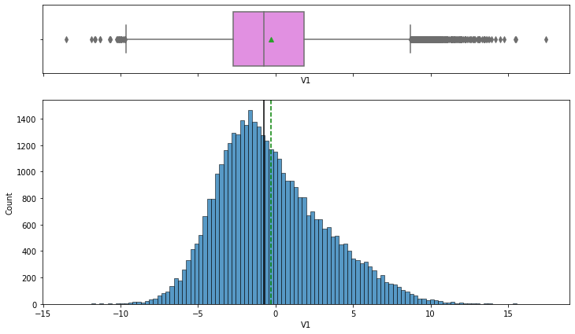

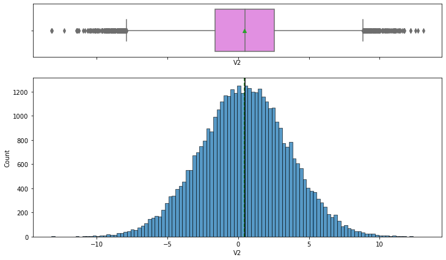

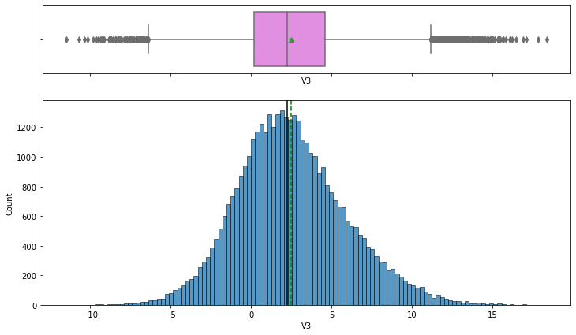

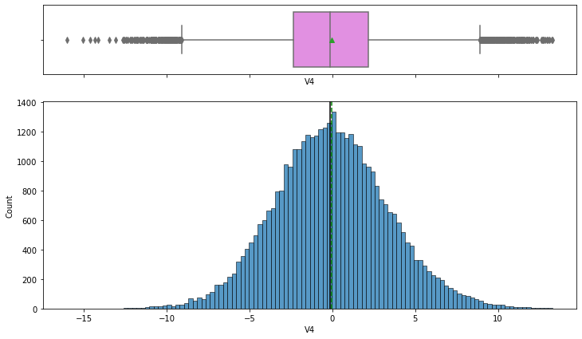

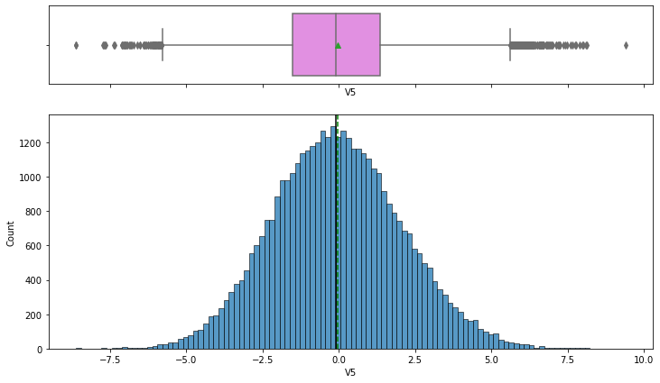

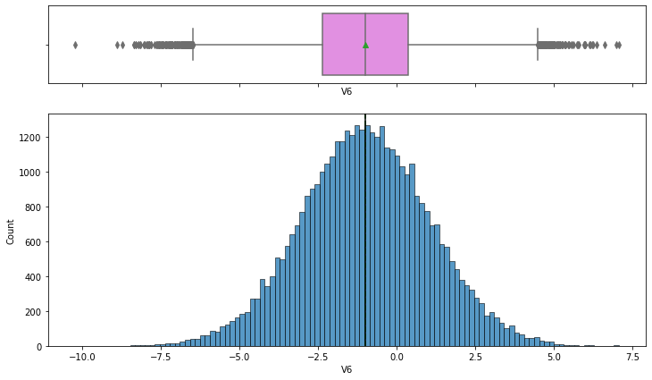

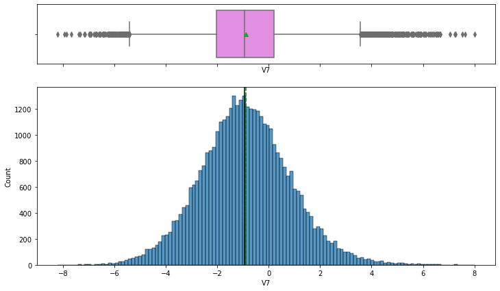

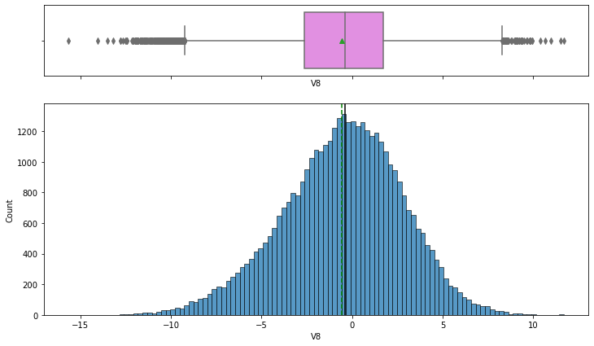

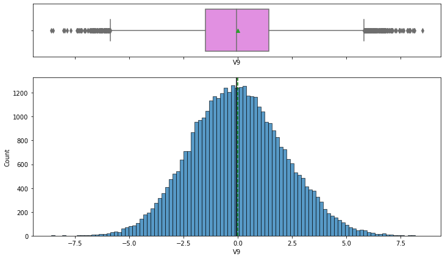

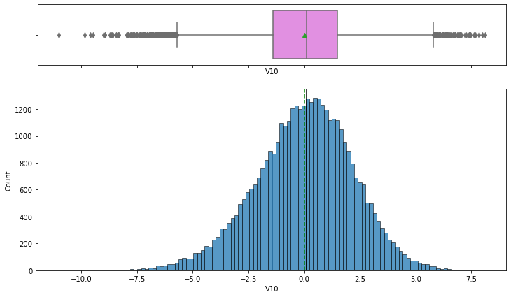

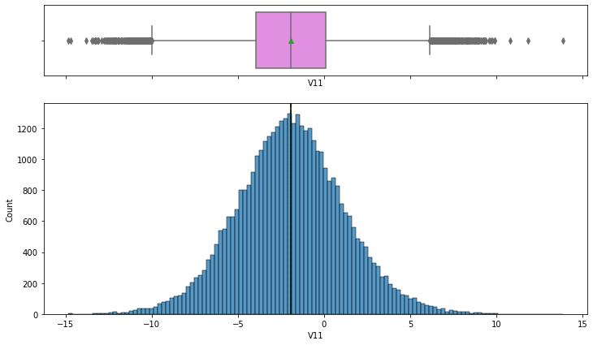

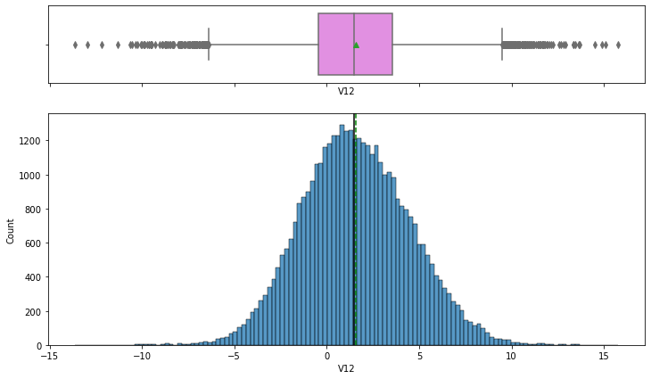

[28 more figures not shown]

```python
 for i in data.columns[0:-1]:
        histogram_boxplot(data,i)
```

```python
data.corr() # It will show correlation matrix
```

|  | V1 | V2 | V3 | V4 | V5 | V6 | V7 | V8 | V9 | V10 | V11 | V12 | V13 | V14 | V15 | V16 | V17 | V18 | V19 | V20 | V21 | V22 | V23 | V24 | V25 | V26 | V27 | V28 | V29 | … |
| --- | --- | --- | --- | --- | --- | --- | --- | --- | --- | --- | --- | --- | --- | --- | --- | --- | --- | --- | --- | --- | --- | --- | --- | --- | --- | --- | --- | --- | --- | --- |
| V1 | 1.000 | 0.311 | 0.391 | -0.301 | -0.518 | 0.174 | 0.483 | -0.361 | 0.399 | -0.017 | 0.291 | -0.144 | 0.065 | -0.268 | 0.414 | -0.335 | -0.355 | -0.392 | 0.125 | -0.341 | -0.395 | 0.207 | -0.437 | -0.520 | 0.678 | 0.224 | 0.689 | -0.286 | -0.069 | … |
| V2 | 0.311 | 1.000 | 0.093 | 0.290 | 0.382 | 0.240 | 0.454 | -0.390 | 0.281 | -0.479 | 0.159 | -0.165 | -0.388 | -0.854 | 0.223 | -0.248 | 0.164 | -0.300 | 0.122 | -0.588 | -0.064 | -0.093 | -0.183 | 0.224 | -0.125 | 0.785 | -0.200 | 0.040 | 0.177 | … |
| V3 | 0.391 | 0.093 | 1.000 | -0.038 | -0.360 | -0.290 | -0.154 | -0.413 | 0.233 | 0.452 | -0.337 | -0.168 | 0.334 | -0.218 | -0.058 | -0.533 | -0.420 | -0.267 | 0.396 | -0.041 | -0.658 | -0.200 | -0.787 | -0.274 | 0.603 | 0.462 | 0.507 | -0.417 | -0.451 | … |
| V4 | -0.301 | 0.290 | -0.038 | 1.000 | 0.081 | -0.465 | -0.197 | 0.032 | 0.268 | -0.114 | -0.358 | -0.233 | -0.276 | -0.227 | -0.154 | -0.197 | 0.612 | -0.410 | 0.598 | 0.416 | -0.082 | -0.030 | 0.040 | 0.513 | -0.274 | 0.099 | -0.589 | 0.667 | -0.178 | … |
| V5 | -0.518 | 0.382 | -0.360 | 0.081 | 1.000 | 0.161 | -0.083 | 0.165 | -0.301 | -0.342 | -0.212 | -0.019 | -0.336 | -0.147 | -0.150 | 0.265 | 0.326 | 0.441 | -0.506 | -0.362 | 0.384 | -0.086 | 0.455 | 0.666 | -0.603 | 0.405 | -0.659 | -0.034 | 0.095 | … |
| V6 | 0.174 | 0.240 | -0.290 | -0.465 | 0.161 | 1.000 | 0.215 | -0.559 | 0.080 | -0.113 | 0.709 | -0.397 | -0.236 | -0.349 | 0.149 | -0.084 | -0.453 | 0.283 | -0.414 | -0.698 | 0.226 | -0.069 | -0.185 | -0.190 | -0.192 | 0.152 | 0.214 | -0.177 | 0.584 | … |
| V7 | 0.483 | 0.454 | -0.154 | -0.197 | -0.083 | 0.215 | 1.000 | 0.086 | -0.241 | -0.171 | 0.533 | 0.392 | -0.495 | -0.322 | 0.870 | 0.397 | 0.022 | -0.563 | 0.137 | -0.414 | 0.469 | -0.276 | -0.054 | -0.212 | 0.204 | 0.022 | 0.293 | 0.189 | 0.310 | … |
| V8 | -0.361 | -0.390 | -0.413 | 0.032 | 0.165 | -0.559 | 0.086 | 1.000 | -0.610 | -0.184 | -0.191 | 0.680 | -0.097 | 0.547 | 0.168 | 0.802 | 0.512 | -0.019 | -0.154 | 0.441 | 0.480 | -0.041 | 0.720 | 0.250 | -0.208 | -0.507 | -0.419 | 0.167 | 0.063 | … |
| V9 | 0.399 | 0.281 | 0.233 | 0.268 | -0.301 | 0.080 | -0.241 | -0.610 | 1.000 | -0.290 | -0.094 | -0.631 | 0.390 | -0.236 | -0.391 | -0.755 | -0.037 | -0.051 | 0.047 | 0.132 | -0.596 | 0.319 | -0.344 | -0.391 | 0.319 | 0.313 | 0.177 | -0.092 | -0.244 | … |
| V10 | -0.017 | -0.479 | 0.452 | -0.114 | -0.342 | -0.113 | -0.171 | -0.184 | -0.290 | 1.000 | -0.153 | -0.122 | 0.070 | 0.338 | 0.087 | -0.116 | -0.515 | -0.148 | 0.408 | 0.050 | -0.124 | -0.189 | -0.466 | -0.013 | 0.282 | -0.215 | 0.506 | 0.023 | -0.431 | … |
| V11 | 0.291 | 0.159 | -0.337 | -0.358 | -0.212 | 0.709 | 0.533 | -0.191 | -0.094 | -0.153 | 1.000 | -0.004 | -0.186 | -0.275 | 0.416 | 0.277 | -0.432 | -0.246 | -0.088 | -0.533 | 0.338 | -0.256 | -0.107 | -0.369 | -0.218 | -0.063 | 0.249 | -0.078 | 0.810 | … |
| V12 | -0.144 | -0.165 | -0.168 | -0.233 | -0.019 | -0.397 | 0.392 | 0.680 | -0.631 | -0.122 | -0.004 | 1.000 | -0.013 | 0.135 | 0.265 | 0.567 | 0.246 | -0.046 | 0.061 | 0.150 | 0.282 | 0.018 | 0.456 | 0.041 | -0.055 | -0.303 | -0.089 | 0.042 | 0.087 | … |
| V13 | 0.065 | -0.388 | 0.334 | -0.276 | -0.336 | -0.236 | -0.495 | -0.097 | 0.390 | 0.070 | -0.186 | -0.013 | 1.000 | 0.375 | -0.680 | -0.312 | -0.454 | 0.254 | -0.203 | 0.231 | -0.609 | 0.277 | -0.057 | -0.495 | 0.174 | 0.081 | 0.304 | -0.657 | -0.346 | … |
| V14 | -0.268 | -0.854 | -0.218 | -0.227 | -0.147 | -0.349 | -0.322 | 0.547 | -0.236 | 0.338 | -0.275 | 0.135 | 0.375 | 1.000 | -0.159 | 0.407 | -0.033 | 0.220 | -0.308 | 0.547 | 0.206 | 0.092 | 0.382 | -0.156 | 0.118 | -0.672 | 0.120 | -0.064 | -0.352 | … |
| V15 | 0.414 | 0.223 | -0.058 | -0.154 | -0.150 | 0.149 | 0.870 | 0.168 | -0.391 | 0.087 | 0.416 | 0.265 | -0.680 | -0.159 | 1.000 | 0.466 | 0.063 | -0.592 | 0.216 | -0.250 | 0.564 | -0.440 | -0.183 | -0.143 | 0.332 | -0.189 | 0.320 | 0.318 | 0.278 | … |
| V16 | -0.335 | -0.248 | -0.533 | -0.197 | 0.265 | -0.084 | 0.397 | 0.802 | -0.755 | -0.116 | 0.277 | 0.567 | -0.312 | 0.407 | 0.466 | 1.000 | 0.215 | -0.124 | -0.280 | 0.036 | 0.834 | -0.430 | 0.535 | 0.106 | -0.324 | -0.432 | -0.253 | 0.120 | 0.418 | … |
| V17 | -0.355 | 0.164 | -0.420 | 0.612 | 0.326 | -0.453 | 0.022 | 0.512 | -0.037 | -0.515 | -0.432 | 0.246 | -0.454 | -0.033 | 0.063 | 0.215 | 1.000 | -0.017 | 0.096 | 0.513 | 0.302 | 0.149 | 0.539 | 0.495 | -0.183 | -0.220 | -0.710 | 0.661 | -0.054 | … |
| V18 | -0.392 | -0.300 | -0.267 | -0.410 | 0.441 | 0.283 | -0.563 | -0.019 | -0.051 | -0.148 | -0.246 | -0.046 | 0.254 | 0.220 | -0.592 | -0.124 | -0.017 | 1.000 | -0.697 | -0.039 | -0.080 | 0.464 | 0.400 | 0.178 | -0.258 | -0.058 | -0.222 | -0.328 | -0.038 | … |
| V19 | 0.125 | 0.122 | 0.396 | 0.598 | -0.506 | -0.414 | 0.137 | -0.154 | 0.047 | 0.408 | -0.088 | 0.061 | -0.203 | -0.308 | 0.216 | -0.280 | 0.096 | -0.697 | 1.000 | 0.249 | -0.264 | -0.117 | -0.429 | 0.131 | 0.172 | -0.027 | 0.093 | 0.532 | -0.205 | … |
| V20 | -0.341 | -0.588 | -0.041 | 0.416 | -0.362 | -0.698 | -0.414 | 0.441 | 0.132 | 0.050 | -0.533 | 0.150 | 0.231 | 0.547 | -0.250 | 0.036 | 0.513 | -0.039 | 0.249 | 1.000 | -0.049 | 0.116 | 0.202 | -0.072 | 0.204 | -0.623 | -0.182 | 0.412 | -0.373 | … |
| V21 | -0.395 | -0.064 | -0.658 | -0.082 | 0.384 | 0.226 | 0.469 | 0.480 | -0.596 | -0.124 | 0.338 | 0.282 | -0.609 | 0.206 | 0.564 | 0.834 | 0.302 | -0.080 | -0.264 | -0.049 | 1.000 | -0.504 | 0.382 | 0.149 | -0.328 | -0.412 | -0.260 | 0.408 | 0.454 | … |
| V22 | 0.207 | -0.093 | -0.200 | -0.030 | -0.086 | -0.069 | -0.276 | -0.041 | 0.319 | -0.189 | -0.256 | 0.018 | 0.277 | 0.092 | -0.440 | -0.430 | 0.149 | 0.464 | -0.117 | 0.116 | -0.504 | 1.000 | 0.427 | 0.159 | 0.029 | -0.104 | -0.057 | -0.018 | -0.334 | … |
| V23 | -0.437 | -0.183 | -0.787 | 0.040 | 0.455 | -0.185 | -0.054 | 0.720 | -0.344 | -0.466 | -0.107 | 0.456 | -0.057 | 0.382 | -0.183 | 0.535 | 0.539 | 0.400 | -0.429 | 0.202 | 0.382 | 0.427 | 1.000 | 0.446 | -0.551 | -0.350 | -0.632 | 0.178 | 0.112 | … |
| V24 | -0.520 | 0.224 | -0.274 | 0.513 | 0.666 | -0.190 | -0.212 | 0.250 | -0.391 | -0.013 | -0.369 | 0.041 | -0.495 | -0.156 | -0.143 | 0.106 | 0.495 | 0.178 | 0.131 | -0.072 | 0.149 | 0.159 | 0.446 | 1.000 | -0.623 | 0.156 | -0.760 | 0.408 | -0.070 | … |
| V25 | 0.678 | -0.125 | 0.603 | -0.274 | -0.603 | -0.192 | 0.204 | -0.208 | 0.319 | 0.282 | -0.218 | -0.055 | 0.174 | 0.118 | 0.332 | -0.324 | -0.183 | -0.258 | 0.172 | 0.204 | -0.328 | 0.029 | -0.551 | -0.623 | 1.000 | -0.099 | 0.772 | -0.151 | -0.478 | … |
| V26 | 0.224 | 0.785 | 0.462 | 0.099 | 0.405 | 0.152 | 0.022 | -0.507 | 0.313 | -0.215 | -0.063 | -0.303 | 0.081 | -0.672 | -0.189 | -0.432 | -0.220 | -0.058 | -0.027 | -0.623 | -0.412 | -0.104 | -0.350 | 0.156 | -0.099 | 1.000 | -0.071 | -0.451 | -0.055 | … |
| V27 | 0.689 | -0.200 | 0.507 | -0.589 | -0.659 | 0.214 | 0.293 | -0.419 | 0.177 | 0.506 | 0.249 | -0.089 | 0.304 | 0.120 | 0.320 | -0.253 | -0.710 | -0.222 | 0.093 | -0.182 | -0.260 | -0.057 | -0.632 | -0.760 | 0.772 | -0.071 | 1.000 | -0.367 | -0.230 | … |
| V28 | -0.286 | 0.040 | -0.417 | 0.667 | -0.034 | -0.177 | 0.189 | 0.167 | -0.092 | 0.023 | -0.078 | 0.042 | -0.657 | -0.064 | 0.318 | 0.120 | 0.661 | -0.328 | 0.532 | 0.412 | 0.408 | -0.018 | 0.178 | 0.408 | -0.151 | -0.451 | -0.367 | 1.000 | 0.002 | … |
| V29 | -0.069 | 0.177 | -0.451 | -0.178 | 0.095 | 0.584 | 0.310 | 0.063 | -0.244 | -0.431 | 0.810 | 0.087 | -0.346 | -0.352 | 0.278 | 0.418 | -0.054 | -0.038 | -0.205 | -0.373 | 0.454 | -0.334 | 0.112 | -0.070 | -0.478 | -0.055 | -0.230 | 0.002 | 1.000 | … |
| V30 | -0.468 | -0.216 | -0.613 | 0.128 | 0.144 | 0.148 | -0.250 | 0.369 | -0.288 | -0.320 | 0.370 | 0.148 | -0.086 | 0.043 | -0.254 | 0.363 | 0.183 | 0.237 | -0.134 | 0.069 | 0.232 | 0.109 | 0.551 | 0.333 | -0.769 | -0.302 | -0.611 | 0.143 | 0.673 | … |
| V31 | 0.089 | -0.046 | 0.468 | -0.384 | 0.300 | -0.111 | -0.034 | 0.145 | -0.458 | 0.409 | -0.231 | 0.038 | 0.035 | 0.175 | 0.136 | 0.208 | -0.375 | 0.057 | -0.228 | -0.372 | -0.026 | -0.294 | -0.170 | 0.148 | 0.152 | 0.335 | 0.197 | -0.560 | -0.224 | … |
| V32 | -0.637 | -0.117 | -0.375 | 0.378 | 0.622 | -0.287 | -0.460 | 0.476 | -0.373 | -0.030 | -0.359 | 0.017 | -0.104 | 0.273 | -0.399 | 0.294 | 0.349 | 0.297 | -0.155 | 0.095 | 0.147 | 0.160 | 0.639 | 0.825 | -0.716 | 0.007 | -0.768 | 0.130 | -0.068 | … |
| V33 | -0.295 | 0.203 | -0.225 | -0.052 | 0.464 | 0.587 | -0.266 | -0.245 | -0.148 | -0.111 | 0.421 | -0.348 | -0.121 | -0.323 | -0.286 | 0.019 | -0.300 | 0.320 | -0.285 | -0.579 | 0.060 | -0.118 | 0.060 | 0.370 | -0.737 | 0.363 | -0.385 | -0.250 | 0.599 | … |
| V34 | -0.017 | -0.277 | 0.226 | 0.302 | -0.609 | -0.399 | 0.233 | 0.049 | -0.093 | 0.511 | -0.059 | 0.230 | -0.114 | 0.137 | 0.367 | 0.037 | 0.072 | -0.609 | 0.758 | 0.504 | 0.111 | -0.320 | -0.361 | -0.226 | 0.374 | -0.459 | 0.322 | 0.561 | -0.248 | … |
| V35 | 0.140 | -0.056 | 0.495 | 0.336 | -0.341 | -0.318 | -0.437 | -0.161 | 0.114 | 0.340 | -0.166 | -0.187 | 0.225 | -0.164 | -0.337 | -0.443 | -0.210 | -0.189 | 0.550 | 0.061 | -0.699 | 0.227 | -0.270 | 0.246 | -0.041 | 0.205 | -0.032 | -0.105 | -0.148 | … |
| V36 | -0.116 | -0.577 | 0.447 | -0.563 | -0.043 | -0.247 | -0.279 | 0.154 | -0.349 | 0.562 | -0.428 | 0.238 | 0.427 | 0.547 | -0.131 | 0.081 | -0.382 | 0.354 | -0.247 | 0.136 | -0.105 | -0.100 | -0.144 | -0.216 | 0.398 | -0.139 | 0.429 | -0.492 | -0.487 | … |
| V37 | -0.352 | -0.441 | -0.502 | -0.348 | 0.066 | -0.075 | -0.014 | 0.529 | -0.201 | -0.405 | -0.049 | 0.549 | 0.170 | 0.428 | -0.089 | 0.434 | 0.352 | 0.478 | -0.504 | 0.430 | 0.386 | 0.149 | 0.575 | -0.236 | -0.035 | -0.562 | -0.155 | 0.018 | 0.147 | … |
| V38 | 0.144 | 0.659 | -0.076 | 0.098 | 0.174 | 0.632 | 0.469 | -0.616 | 0.039 | -0.006 | 0.472 | -0.214 | -0.569 | -0.765 | 0.351 | -0.237 | -0.127 | -0.192 | 0.269 | -0.644 | 0.161 | -0.163 | -0.341 | 0.173 | -0.196 | 0.377 | 0.047 | 0.305 | 0.336 | … |
| V39 | -0.112 | -0.347 | 0.538 | -0.388 | -0.216 | -0.026 | -0.236 | -0.347 | 0.004 | 0.567 | -0.245 | 0.042 | 0.482 | 0.185 | -0.230 | -0.288 | -0.513 | 0.218 | 0.029 | 0.076 | -0.242 | -0.187 | -0.489 | -0.405 | 0.382 | 0.026 | 0.546 | -0.340 | -0.433 | … |
| V40 | 0.213 | 0.152 | -0.301 | -0.669 | 0.337 | 0.422 | 0.477 | 0.257 | -0.314 | -0.467 | 0.335 | 0.311 | -0.252 | -0.048 | 0.434 | 0.477 | 0.028 | 0.290 | -0.700 | -0.418 | 0.465 | -0.088 | 0.270 | -0.193 | 0.076 | 0.001 | 0.071 | -0.333 | 0.449 | … |
| Target | 0.072 | 0.003 | -0.217 | 0.116 | -0.100 | -0.006 | 0.240 | 0.137 | 0.011 | -0.057 | 0.191 | -0.014 | -0.140 | 0.114 | 0.247 | 0.227 | 0.095 | -0.292 | 0.058 | 0.075 | 0.254 | -0.123 | 0.078 | -0.087 | -0.002 | -0.182 | 0.011 | 0.214 | 0.102 | … |

```python
def plot_corr(data, size=20):
    corr = data.corr()
    fig, ax = plt.subplots(figsize=(size, size))
    ax.matshow(corr)
    plt.xticks(range(len(corr.columns)), corr.columns)
    plt.yticks(range(len(corr.columns)), corr.columns)
    for (i, j), z in np.ndenumerate(corr):
        ax.text(j, i, '{:0.1f}'.format(z), ha='center', va='center')
```

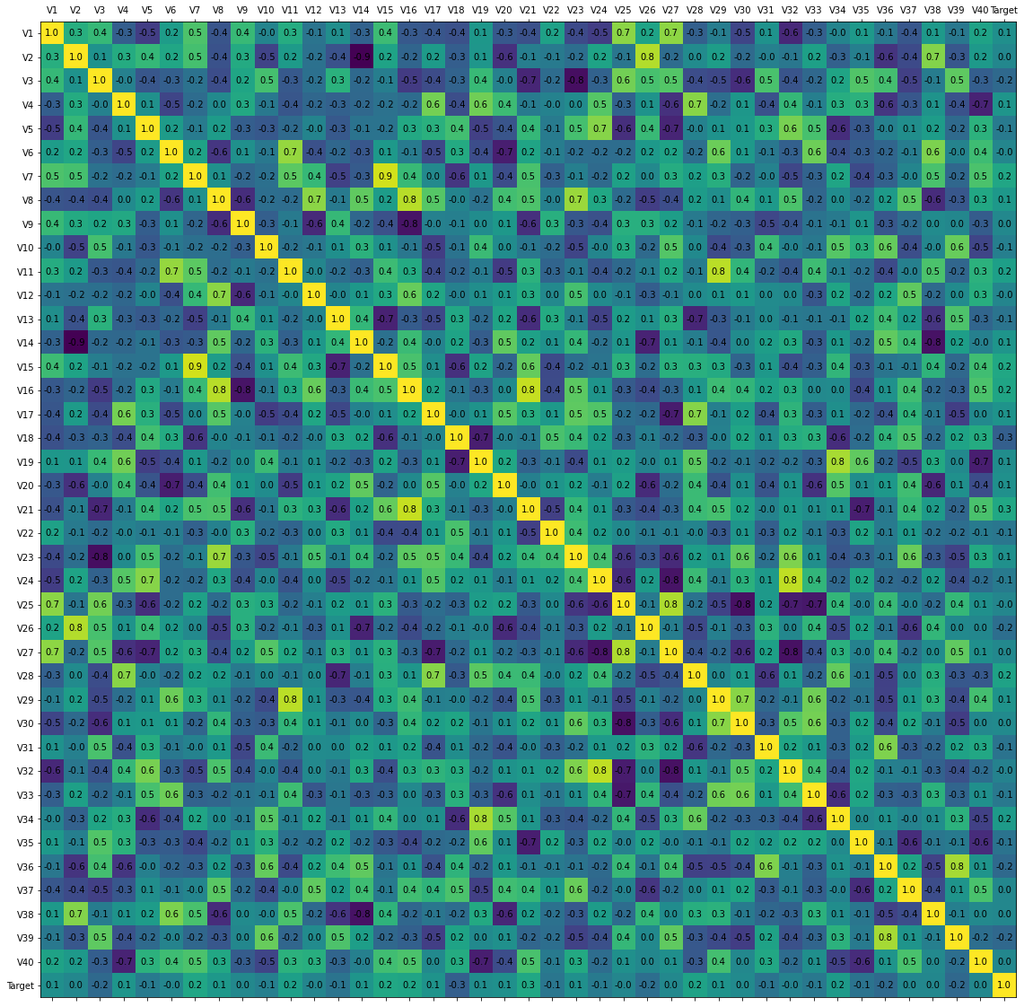

```python
plot_corr(data)
```

V2 shows high corelation with v14,V3 shows high corelation with v23, V9 and V16 show high co-relation.V14 and V38.V7 and V15 show a high co-relation as well.These are more like 0.8 and 0.9.Most of the other variables do not show a high co-relation.

```python
# function to create labeled barplots


def labeled_barplot(data, feature, perc=True, n=None):
    """
    Barplot with percentage at the top

    data: dataframe
    feature: dataframe column
    perc: whether to display percentages instead of count (default is False)
    n: displays the top n category levels (default is None, i.e., display all levels)
    """

    total = len(data[feature])  # length of the column
    count = data[feature].nunique()
    if n is None:
        plt.figure(figsize=(count + 1, 5))
    else:
        plt.figure(figsize=(n + 1, 5))

    plt.xticks(rotation=90, fontsize=15)
    ax = sns.countplot(
        data=data,
        x=feature,
        palette="Paired",
        order=data[feature].value_counts().index[:n].sort_values(),
    )

    for p in ax.patches:
        if perc == True:
            label = "{:.1f}%".format(
                100 * p.get_height() / total
            )  # percentage of each class of the category
        else:
            label = p.get_height()  # count of each level of the category

        x = p.get_x() + p.get_width() / 2  # width of the plot
        y = p.get_height()  # height of the plot

        ax.annotate(
            label,
            (x, y),
            ha="center",
            va="center",
            size=12,
            xytext=(0, 5),
            textcoords="offset points",
        )  # annotate the percentage

    plt.show()  # show the plot
```

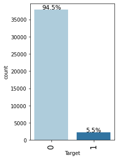

```python
labeled_barplot(data,"Target")
```

### Observation

The class distribution in the target variable is imbalanced. 94.5% of the Target value indicates no failure and very small percentage of the Target indicates a failure 5.5%. This also means the model will be heavily skewed to the "0".we will need to balance that by Oversampling and undersampling.

## Data PreProcessing

```python
#make another copy of the data.
df = data.copy()
```

```python
X = df.drop(["Target"], axis=1)
y = df["Target"]
```

```python
# Splitting data into training, validation and test sets:
# first we split data into 2 parts, say temporary and test

X_temp, X_test, y_temp, y_test = train_test_split(
    X, y, test_size=0.2, random_state=1, stratify=y
)

# then we split the temporary set into train and validation

X_train, X_val, y_train, y_val = train_test_split(
    X_temp, y_temp, test_size=0.25, random_state=1, stratify=y_temp
)
print(X_train.shape, X_val.shape, X_test.shape)
```

```
(24000, 40) (8000, 40) (8000, 40)
```

#### Missing value treatment for V1 and V2.

```python
# Let's impute the missing values
imp_mode = SimpleImputer(missing_values=np.nan, strategy="median")
cols_to_impute = ["V1", "V2"]

# fit and transform the imputer on train data
X_train[cols_to_impute] = imp_mode.fit_transform(X_train[cols_to_impute])

# Transform on validation and test data
X_val[cols_to_impute] = imp_mode.transform(X_val[cols_to_impute])

# fit and transform the imputer on test data
X_test[cols_to_impute] = imp_mode.transform(X_test[cols_to_impute])
```

#### Building Model for evaluation of the data

```python
# defining a function to compute different metrics to check performance of a classification model built using sklearn
def model_performance_classification_sklearn(model, predictors, target):
    """
    Function to compute different metrics to check classification model performance

    model: classifier
    predictors: independent variables
    target: dependent variable
    """

    TP = confusion_matrix(target, model.predict(predictors))[1, 1]
    FP = confusion_matrix(target, model.predict(predictors))[0, 1]
    FN = confusion_matrix(target, model.predict(predictors))[1, 0]
    Cost = TP * 15 + FP * 5 + FN * 40  # maintenance cost by using model
    Min_Cost = (TP + FN) * 15  # minimum possible maintenance cost = number of actual positives
    Percent = Min_Cost / Cost  # ratio of minimum possible maintenance cost and maintenance cost by model

    # predicting using the independent variables
    pred = model.predict(predictors)

    acc = accuracy_score(target, pred)  # to compute Accuracy
    recall = recall_score(target, pred)  # to compute Recall
    precision = precision_score(target, pred)  # to compute Precision
    f1 = f1_score(target, pred)  # to compute F1-score

    # creating a dataframe of metrics
    df_perf = pd.DataFrame(
        {
            "Accuracy": acc,
            "Recall": recall,
            "Precision": precision,
            "F1": f1,
            "Minimum_Vs_Model_cost": Percent,
        },
        index=[0],
    )

    return df_perf
```

```python
def confusion_matrix_sklearn(model, predictors, target):
    """
    To plot the confusion_matrix with percentages

    model: classifier
    predictors: independent variables
    target: dependent variable
    """
    y_pred = model.predict(predictors)
    cm = confusion_matrix(target, y_pred)
    labels = np.asarray(
        [
            ["{0:0.0f}".format(item) + "\n{0:.2%}".format(item / cm.flatten().sum())]
            for item in cm.flatten()
        ]
    ).reshape(2, 2)

    plt.figure(figsize=(6, 4))
    sns.heatmap(cm, annot=labels, fmt="")
    plt.ylabel("True label")
    plt.xlabel("Predicted label")
```

### Model 1 with regular data using Logistic Regression

```python
lr = LogisticRegression(random_state=1)
lr.fit(X_train, y_train)
```

```
LogisticRegression(random_state=1)
```

```python
model_performance_classification_sklearn(lr, X_train, y_train)
```

|  | Accuracy | Recall | Precision | F1 | Minimum_Vs_Model_cost |
| --- | --- | --- | --- | --- | --- |
| 0 | 0.967 | 0.478 | 0.857 | 0.614 | 0.527 |

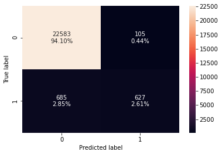

```python
confusion_matrix_sklearn(lr, X_train, y_train)
```

### Observation

The Accuracy is quite high maybe overfitting.Recall is poor at 47%.Minimum_Vs_Model_cost is at 52%. which is not good.

### Model 2 with regular data using Decision Tree.

```python
dTree = DecisionTreeClassifier(criterion = 'gini', random_state=1)
dTree.fit(X_train, y_train)
```

```
DecisionTreeClassifier(random_state=1)
```

```python
model_performance_classification_sklearn(dTree, X_train, y_train)
```

|  | Accuracy | Recall | Precision | F1 | Minimum_Vs_Model_cost |
| --- | --- | --- | --- | --- | --- |
| 0 | 1.000 | 1.000 | 1.000 | 1.000 | 1.000 |

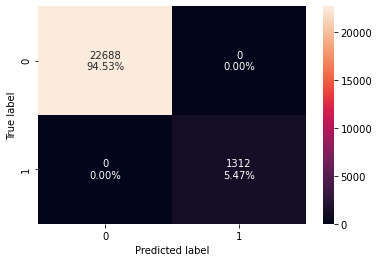

```python
confusion_matrix_sklearn(dTree, X_train, y_train)
```

### Observation

Decision Tree is overfitting by 100% we should look at the tuned model to get a better picture.The imalanced data is creating the overfitting which should be fixed by performing over sampling or undersampling.

### Model 3 Random Forest Classifier

```python
#Train the random forest classifier
rf_estimator=RandomForestClassifier(random_state=1)
rf_estimator.fit(X_train,y_train)
```

```
RandomForestClassifier(random_state=1)
```

```python
model_performance_classification_sklearn(rf_estimator, X_train, y_train)
```

|  | Accuracy | Recall | Precision | F1 | Minimum_Vs_Model_cost |
| --- | --- | --- | --- | --- | --- |
| 0 | 1.000 | 0.999 | 1.000 | 1.000 | 0.999 |

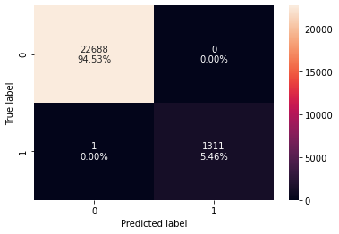

```python
confusion_matrix_sklearn(rf_estimator, X_train, y_train)
```

### Observation

This model is also overfitting the data we need to tune it to get a workable model.The imalanced data is creating the overfitting which should be fixed by performing over sampling or undersampling.

### Model 4 Bagging Classifier Model

```python
bagging_estimator=BaggingClassifier(random_state=1)
bagging_estimator.fit(X_train,y_train)
```

```
BaggingClassifier(random_state=1)
```

```python
model_performance_classification_sklearn(bagging_estimator, X_train, y_train)
```

|  | Accuracy | Recall | Precision | F1 | Minimum_Vs_Model_cost |
| --- | --- | --- | --- | --- | --- |
| 0 | 0.997 | 0.950 | 0.999 | 0.974 | 0.922 |

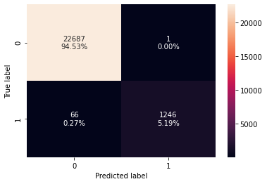

```python
confusion_matrix_sklearn(bagging_estimator, X_train, y_train)
```

#### Observation

This model is overfitting the data as well. But less than the previous models. we need to tune the model to get a workable solution.

### Model 5 AdaBoost classifier

```python
ab_classifier = AdaBoostClassifier(random_state=1)
ab_classifier.fit(X_train,y_train)
```

```
AdaBoostClassifier(random_state=1)
```

```python
model_performance_classification_sklearn(ab_classifier, X_train, y_train)
```

|  | Accuracy | Recall | Precision | F1 | Minimum_Vs_Model_cost |
| --- | --- | --- | --- | --- | --- |
| 0 | 0.976 | 0.622 | 0.905 | 0.737 | 0.605 |

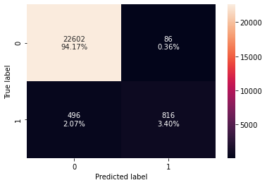

```python
confusion_matrix_sklearn(ab_classifier, X_train, y_train)
```

#### Observation

This model is overfitting on the Accuracy and precision. However the recall is low.Minimum_Vs_Model_cost is also only 60%.

### Model 6 XGBClassifier Model

```python
xgb = XGBClassifier(random_state=1,eval_metric='logloss')
xgb.fit(X_train,y_train)
```

```
XGBClassifier(base_score=0.5, booster='gbtree', colsample_bylevel=1,
              colsample_bynode=1, colsample_bytree=1, eval_metric='logloss',
              gamma=0, gpu_id=-1, importance_type='gain',
              interaction_constraints='', learning_rate=0.300000012,
              max_delta_step=0, max_depth=6, min_child_weight=1, missing=nan,
              monotone_constraints='()', n_estimators=100, n_jobs=6,
              num_parallel_tree=1, random_state=1, reg_alpha=0, reg_lambda=1,
              scale_pos_weight=1, subsample=1, tree_method='exact',
              validate_parameters=1, verbosity=None)
```

```python
model_performance_classification_sklearn(xgb, X_train, y_train)
```

|  | Accuracy | Recall | Precision | F1 | Minimum_Vs_Model_cost |
| --- | --- | --- | --- | --- | --- |
| 0 | 1.000 | 1.000 | 1.000 | 1.000 | 1.000 |

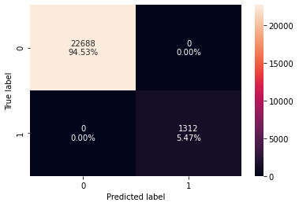

```python
confusion_matrix_sklearn(xgb, X_train, y_train)
```

#### Observation

This model is also overfitting the data and will need to be tuned in order to make a workable solution.The imalanced data is creating the overfitting which should be fixed by performing over sampling or undersampling.

## Model Building with Oversampling.

### Model 1 with Logistic Regression.

```python
print("Before UpSampling, counts of label 'Yes': {}".format(sum(y_train == 1)))
print("Before UpSampling, counts of label 'No': {} \n".format(sum(y_train == 0)))

sm = SMOTE(
    sampling_strategy=1, k_neighbors=5, random_state=1
)  # Synthetic Minority Over Sampling Technique
X_train_over, y_train_over = sm.fit_resample(X_train, y_train)


print("After UpSampling, counts of label 'Yes': {}".format(sum(y_train_over == 1)))
print("After UpSampling, counts of label 'No': {} \n".format(sum(y_train_over == 0)))


print("After UpSampling, the shape of train_X: {}".format(X_train_over.shape))
print("After UpSampling, the shape of train_y: {} \n".format(y_train_over.shape))
```

```
Before UpSampling, counts of label 'Yes': 1312
Before UpSampling, counts of label 'No': 22688

After UpSampling, counts of label 'Yes': 22688
After UpSampling, counts of label 'No': 22688

After UpSampling, the shape of train_X: (45376, 40)
After UpSampling, the shape of train_y: (45376,)
```

```python
log_reg_over = LogisticRegression(random_state=1)

# Training the basic logistic regression model with training set
log_reg_over.fit(X_train_over, y_train_over)
```

```
LogisticRegression(random_state=1)
```

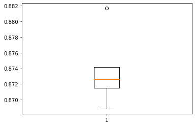

```python
scoring = "recall"
kfold = StratifiedKFold(
    n_splits=5, shuffle=True, random_state=1
)  # Setting number of splits equal to 5
cv_result_over = cross_val_score(
    estimator=log_reg_over, X=X_train_over, y=y_train_over, scoring=scoring, cv=kfold
)
# Plotting boxplots for CV scores of model defined above
plt.boxplot(cv_result_over)
plt.show()
```

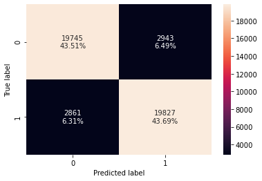

```python
confusion_matrix_sklearn(log_reg_over, X_train_over, y_train_over)
```

```python
log_reg_over_train = model_performance_classification_sklearn(log_reg_over, X_train_over, y_train_over)
print("Training performance")
log_reg_over_train
```

```
Training performance
```

|  | Accuracy | Recall | Precision | F1 | Minimum_Vs_Model_cost |
| --- | --- | --- | --- | --- | --- |
| 0 | 0.872 | 0.874 | 0.871 | 0.872 | 0.798 |

```python
# Calculating different metrics on validation set
log_reg_over_val_perf = model_performance_classification_sklearn(
    log_reg_over, X_val, y_val
)
print("Validation performance:")
log_reg_over_val_perf
```

```
Validation performance:
```

|  | Accuracy | Recall | Precision | F1 | Minimum_Vs_Model_cost |
| --- | --- | --- | --- | --- | --- |
| 0 | 0.868 | 0.865 | 0.275 | 0.418 | 0.504 |

#### Observation

This model is better than the one with regular data without oversampling. So it is not overfitting but the Minimum_Vs_Model_cost is at 79%.The validation is also performing poorly Minimum_Vs_Model_cost is at 50%.

#### Let us try Regularization with oversampling

```python
# Choose the type of classifier.
lr_Regular_estimator = LogisticRegression(random_state=1, solver="saga")

# Grid of parameters to choose from
parameters = {"C": np.arange(0.1, 1.1, 0.1)}

# Run the grid search
grid_obj = GridSearchCV(lr_Regular_estimator, parameters, scoring="recall")
grid_obj = grid_obj.fit(X_train_over, y_train_over)

# Set the clf to the best combination of parameters
lr_Regular_estimator = grid_obj.best_estimator_

# Fit the best algorithm to the data.
lr_Regular_estimator.fit(X_train_over, y_train_over)
```

```
LogisticRegression(C=0.1, random_state=1, solver='saga')
```

```python
lr_Regular_estimator_train = model_performance_classification_sklearn(lr_Regular_estimator, X_train_over, y_train_over)

print("Training performance:")
lr_Regular_estimator_train
```

```
Training performance:
```

|  | Accuracy | Recall | Precision | F1 | Minimum_Vs_Model_cost |
| --- | --- | --- | --- | --- | --- |
| 0 | 0.872 | 0.874 | 0.871 | 0.872 | 0.798 |

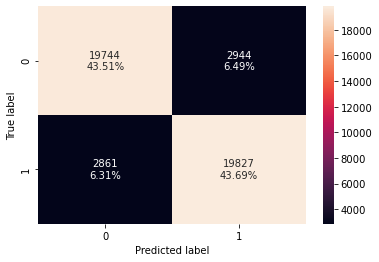

```python
confusion_matrix_sklearn(lr_Regular_estimator, X_train_over, y_train_over)
```

```python
# Calculating different metrics on validation set
lr_Regular_estimator_val_perf = model_performance_classification_sklearn(
    lr_Regular_estimator, X_val, y_val
)
print("Validation performance:")
lr_Regular_estimator_val_perf
```

```
Validation performance:
```

|  | Accuracy | Recall | Precision | F1 | Minimum_Vs_Model_cost |
| --- | --- | --- | --- | --- | --- |
| 0 | 0.868 | 0.865 | 0.275 | 0.418 | 0.504 |

#### Observation

Accuracy and recall and precision and F1 all look good. Minimum_Vs_Model_cost is at 79%. The Validation data is performing poorly on this model.Minimum_Vs_Model_cost is 50%.

### Model 2 with Decision Tree With OverSampling

```python
dTree_over = DecisionTreeClassifier(criterion = 'gini', random_state=1)
dTree_over.fit(X_train_over, y_train_over)
```

```
DecisionTreeClassifier(random_state=1)
```

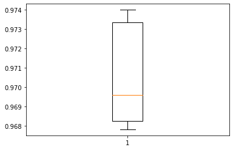

```python
scoring = "recall"
kfold = StratifiedKFold(
    n_splits=5, shuffle=True, random_state=1
)  # Setting number of splits equal to 5
cv_result_over = cross_val_score(
    estimator=dTree_over, X=X_train_over, y=y_train_over, scoring=scoring, cv=kfold
)
# Plotting boxplots for CV scores of model defined above
plt.boxplot(cv_result_over)
plt.show()
```

```python
model_performance_classification_sklearn(dTree_over, X_train_over, y_train_over)
```

|  | Accuracy | Recall | Precision | F1 | Minimum_Vs_Model_cost |
| --- | --- | --- | --- | --- | --- |
| 0 | 1.000 | 1.000 | 1.000 | 1.000 | 1.000 |

```python
## This is overfitting let us try Regularization
dTree_over_reg = DecisionTreeClassifier(random_state=1)

# Parameter grid to pass in RandomizedSearchCV
param_grid = {
    "criterion": ["gini", "entropy"],
    "max_depth": [3, 4, 5, None],
    "min_samples_split": [2, 4, 7, 10, 15],
    'min_impurity_decrease': [0.0001,0.001]
}
# Type of scoring used to compare parameter combinations
scorer = metrics.make_scorer(metrics.recall_score)

# Calling RandomizedSearchCV
randomized_cv_dTree = RandomizedSearchCV(
    estimator=dTree_over_reg,
    param_distributions=param_grid,
    n_iter=20,
    scoring=scorer,
    cv=5,
    random_state=1,
)

# Fitting parameters in RandomizedSearchCV
randomized_cv_dTree.fit(X_train_over, y_train_over)

print(
    "Best parameters are {} with CV score={}:".format(
        randomized_cv_dTree.best_params_, randomized_cv_dTree.best_score_
    )
)
```

```
Best parameters are {'min_samples_split': 10, 'min_impurity_decrease': 0.0001, 'max_depth': None, 'criterion': 'entropy'} with CV score=0.9675160885187392:
```

```python
randomized_cv_dTree_train = model_performance_classification_sklearn( randomized_cv_dTree, X_train_over, y_train_over)
print("Training performance")
randomized_cv_dTree_train
```

```
Training performance
```

|  | Accuracy | Recall | Precision | F1 | Minimum_Vs_Model_cost |
| --- | --- | --- | --- | --- | --- |
| 0 | 0.996 | 0.996 | 0.996 | 0.996 | 0.991 |

```python
# Calculating different metrics on validation set
randomized_cv_dTree_val_perf = model_performance_classification_sklearn(
    randomized_cv_dTree, X_val, y_val
)
print("Validation performance:")
randomized_cv_dTree_val_perf
```

```
Validation performance:
```

|  | Accuracy | Recall | Precision | F1 | Minimum_Vs_Model_cost |
| --- | --- | --- | --- | --- | --- |
| 0 | 0.954 | 0.849 | 0.551 | 0.668 | 0.675 |

### Observation

The Decision Tree with Oversampling with SMOTE and K-fold cross validation/ radomsearchCV is also Overfitting the data. The Validation set is performing poorly with this model. Minimum_Vs_Model_cost is only 67%.

### Model 3 Random Forest Classifier Over Sampling.

```python
#Train the random forest classifier
rf_estimator_over=RandomForestClassifier(random_state=1)
rf_estimator_over.fit(X_train_over,y_train_over)
```

```
RandomForestClassifier(random_state=1)
```

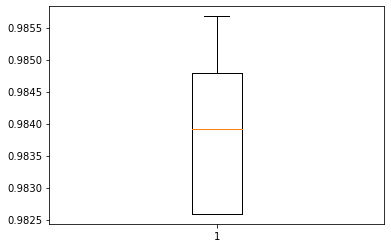

```python
scoring = "recall"
kfold = StratifiedKFold(
    n_splits=5, shuffle=True, random_state=1
)  # Setting number of splits equal to 5
cv_result_over = cross_val_score(
    estimator=rf_estimator_over, X=X_train_over, y=y_train_over, scoring=scoring, cv=kfold
)
# Plotting boxplots for CV scores of model defined above
plt.boxplot(cv_result_over)
plt.show()
```

```python
rf_estimator_over_train = model_performance_classification_sklearn(rf_estimator_over, X_train_over, y_train_over)
print("Training Performance")
rf_estimator_over_train
```

```
Training Performance
```

|  | Accuracy | Recall | Precision | F1 | Minimum_Vs_Model_cost |
| --- | --- | --- | --- | --- | --- |
| 0 | 1.000 | 1.000 | 1.000 | 1.000 | 1.000 |

```python
## This is overfitting let us try Regularization
rf_estimator_over_reg=RandomForestClassifier(random_state=1)

# Parameter grid to pass in RandomizedSearchCV
param_grid = {
    "n_estimators": [150,250],
    "min_samples_leaf": np.arange(1, 3),
    "max_features": ['sqrt','log2'],
    "max_samples": np.arange(0.2, 0.6, 0.1)

}
# Type of scoring used to compare parameter combinations
scorer = metrics.make_scorer(metrics.recall_score)

# Calling RandomizedSearchCV
randomized_cv_rf_estimator = RandomizedSearchCV(
    estimator=rf_estimator_over_reg,
    param_distributions=param_grid,
    n_iter=20,
    scoring=scorer,
    cv=5,
    random_state=1,
)

# Fitting parameters in RandomizedSearchCV
randomized_cv_rf_estimator.fit(X_train_over, y_train_over)

print(
    "Best parameters are {} with CV score={}:".format(
        randomized_cv_rf_estimator.best_params_, randomized_cv_rf_estimator.best_score_
    )
)
```

```
Best parameters are {'n_estimators': 250, 'min_samples_leaf': 1, 'max_samples': 0.5000000000000001, 'max_features': 'sqrt'} with CV score=0.9772123686416364:
```

```python
randomized_cv_rf_estimator_train = model_performance_classification_sklearn(randomized_cv_rf_estimator, X_train_over, y_train_over)
print("Training performance")
randomized_cv_rf_estimator_train
```

```
Training performance
```

|  | Accuracy | Recall | Precision | F1 | Minimum_Vs_Model_cost |
| --- | --- | --- | --- | --- | --- |
| 0 | 0.999 | 0.998 | 1.000 | 0.999 | 0.997 |

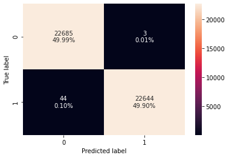

```python
confusion_matrix_sklearn(randomized_cv_rf_estimator, X_train_over, y_train_over)
```

```python
# Calculating different metrics on validation set
randomized_cv_rf_estimator_val_perf = model_performance_classification_sklearn(
    randomized_cv_rf_estimator, X_val, y_val
)
print("Validation performance:")
randomized_cv_rf_estimator_val_perf
```

```
Validation performance:
```

|  | Accuracy | Recall | Precision | F1 | Minimum_Vs_Model_cost |
| --- | --- | --- | --- | --- | --- |
| 0 | 0.988 | 0.881 | 0.902 | 0.891 | 0.813 |

### Observation

This model is overfitting on the precision, the rest of the metric is also appearing to overfit on training data, we can validate it on Validation data set to see the results and know if it a good model to pick.The validation model performance is good and can be improved by tuning the hyper parameters.

### Model 4 Bagging Classifier Over Sampling.

```python
bagging_estimator_over=BaggingClassifier(random_state=1)
bagging_estimator_over.fit(X_train_over,y_train_over)
```

```
BaggingClassifier(random_state=1)
```

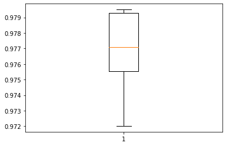

```python
scoring = "recall"
kfold = StratifiedKFold(
    n_splits=5, shuffle=True, random_state=1
)  # Setting number of splits equal to 5
cv_result_over = cross_val_score(
    estimator=bagging_estimator_over, X=X_train_over, y=y_train_over, scoring=scoring, cv=kfold
)
# Plotting boxplots for CV scores of model defined above
plt.boxplot(cv_result_over)
plt.show()
```

```python
model_performance_classification_sklearn(bagging_estimator_over, X_train_over, y_train_over)
```

|  | Accuracy | Recall | Precision | F1 | Minimum_Vs_Model_cost |
| --- | --- | --- | --- | --- | --- |
| 0 | 0.999 | 0.999 | 1.000 | 0.999 | 0.998 |

```python
## This is overfitting let us try Regularization
bagging_estimator_over_reg=BaggingClassifier(random_state=1)

# Parameter grid to pass in RandomizedSearchCV
param_grid = {
    "n_estimators": [40,50],
    "max_features": [0.8,0.9],
    "max_samples": np.arange(0.2, 0.6, 0.1)

}
# Type of scoring used to compare parameter combinations
scorer = metrics.make_scorer(metrics.recall_score)

# Calling RandomizedSearchCV
randomized_cv_bg_over_reg = RandomizedSearchCV(
    estimator=bagging_estimator_over_reg,
    param_distributions=param_grid,
    n_iter=20,
    scoring=scorer,
    cv=5,
    random_state=1,
)

# Fitting parameters in RandomizedSearchCV
randomized_cv_bg_over_reg .fit(X_train_over, y_train_over)

print(
    "Best parameters are {} with CV score={}:".format(
        randomized_cv_bg_over_reg.best_params_, randomized_cv_bg_over_reg.best_score_
    )
)
```

```
Best parameters are {'n_estimators': 50, 'max_samples': 0.5000000000000001, 'max_features': 0.8} with CV score=0.9753172023807384:
```

```python
randomized_cv_bg_over_reg_train = model_performance_classification_sklearn(randomized_cv_bg_over_reg, X_train_over, y_train_over)
print("Training Performance")
randomized_cv_bg_over_reg_train
```

```
Training Performance
```

|  | Accuracy | Recall | Precision | F1 | Minimum_Vs_Model_cost |
| --- | --- | --- | --- | --- | --- |
| 0 | 0.998 | 0.996 | 0.999 | 0.998 | 0.994 |

```python
# Calculating different metrics on validation set
randomized_cv_bg_over_reg_val_perf = model_performance_classification_sklearn(
    randomized_cv_bg_over_reg, X_val, y_val
)
print("Validation performance:")
randomized_cv_bg_over_reg_val_perf
```

```
Validation performance:
```

|  | Accuracy | Recall | Precision | F1 | Minimum_Vs_Model_cost |
| --- | --- | --- | --- | --- | --- |
| 0 | 0.984 | 0.879 | 0.837 | 0.857 | 0.794 |

### Observation

This model is overfitting the training data.Need to tune it and validate the model on validation set to understand if this can be a solution.The Validation set is giving a good performance and should be tuned for better fitting.

### Model 5 AdaBoost Classifier OverSampling

```python
ab_classifier_over = AdaBoostClassifier(random_state=1)
ab_classifier_over.fit(X_train_over,y_train_over)
```

```
AdaBoostClassifier(random_state=1)
```

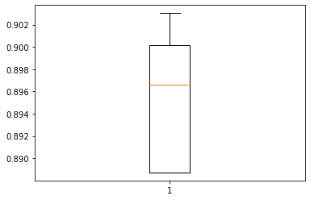

```python
scoring = "recall"
kfold = StratifiedKFold(
    n_splits=5, shuffle=True, random_state=1
)  # Setting number of splits equal to 5
cv_result_over = cross_val_score(
    estimator=ab_classifier_over, X=X_train_over, y=y_train_over, scoring=scoring, cv=kfold
)
# Plotting boxplots for CV scores of model defined above
plt.boxplot(cv_result_over)
plt.show()
```

```python
ab_classifier_over_train = model_performance_classification_sklearn(ab_classifier_over, X_train_over, y_train_over)
print("Training performance")
ab_classifier_over_train
```

```
Training performance
```

|  | Accuracy | Recall | Precision | F1 | Minimum_Vs_Model_cost |
| --- | --- | --- | --- | --- | --- |
| 0 | 0.907 | 0.895 | 0.917 | 0.906 | 0.832 |

```python
# Calculating different metrics on validation set
ab_classifier_over_val_perf = model_performance_classification_sklearn(
    ab_classifier_over, X_val, y_val
)
print("Validation performance:")
ab_classifier_over_val_perf
```

```
Validation performance:
```

|  | Accuracy | Recall | Precision | F1 | Minimum_Vs_Model_cost |
| --- | --- | --- | --- | --- | --- |
| 0 | 0.911 | 0.886 | 0.369 | 0.521 | 0.590 |

### Observation

This model with oversampling is fitting the data better than the regular data.The scores are improved and the Minimum_Vs_Model_cost has improved from 60% to 83%. The validation set performace is poor only 59% is showing up for Minimum_Vs_Model_cost.

### Model 6 XGBoost Classifier OverSampling

```python
xgb_over = XGBClassifier(random_state=1,eval_metric='logloss')
xgb_over.fit(X_train_over,y_train_over)
```

```
XGBClassifier(base_score=0.5, booster='gbtree', colsample_bylevel=1,
              colsample_bynode=1, colsample_bytree=1, eval_metric='logloss',
              gamma=0, gpu_id=-1, importance_type='gain',
              interaction_constraints='', learning_rate=0.300000012,
              max_delta_step=0, max_depth=6, min_child_weight=1, missing=nan,
              monotone_constraints='()', n_estimators=100, n_jobs=6,
              num_parallel_tree=1, random_state=1, reg_alpha=0, reg_lambda=1,
              scale_pos_weight=1, subsample=1, tree_method='exact',
              validate_parameters=1, verbosity=None)
```

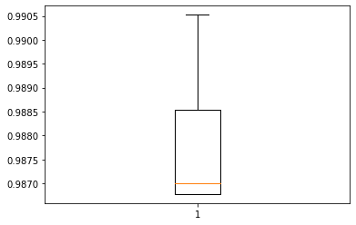

```python
scoring = "recall"
kfold = StratifiedKFold(
    n_splits=5, shuffle=True, random_state=1
)  # Setting number of splits equal to 5
cv_result_over = cross_val_score(
    estimator=xgb_over, X=X_train_over, y=y_train_over, scoring=scoring, cv=kfold
)
# Plotting boxplots for CV scores of model defined above
plt.boxplot(cv_result_over)
plt.show()
```

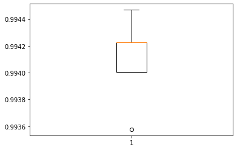

```python
scoring = "precision"
kfold = StratifiedKFold(
    n_splits=5, shuffle=True, random_state=1
)  # Setting number of splits equal to 5
cv_result_over = cross_val_score(
    estimator=xgb_over, X=X_train_over, y=y_train_over, scoring=scoring, cv=kfold
)
# Plotting boxplots for CV scores of model defined above
plt.boxplot(cv_result_over)
plt.show()
```

```python
xgb_over_train = model_performance_classification_sklearn(xgb_over, X_train_over, y_train_over)
print("Testing Performance")
xgb_over_train
```

```
Testing Performance
```

|  | Accuracy | Recall | Precision | F1 | Minimum_Vs_Model_cost |
| --- | --- | --- | --- | --- | --- |
| 0 | 1.000 | 0.999 | 1.000 | 1.000 | 0.999 |

```python
# Calculating different metrics on validation set
xgb_over_val_perf = model_performance_classification_sklearn(
    xgb_over, X_val, y_val
)
print("Validation performance:")
xgb_over_val_perf
```

```
Validation performance:
```

|  | Accuracy | Recall | Precision | F1 | Minimum_Vs_Model_cost |
| --- | --- | --- | --- | --- | --- |
| 0 | 0.988 | 0.886 | 0.886 | 0.886 | 0.814 |

### Observation

This over sampling model is overfitting with respect to accuracy and precision, slightly better than the model with regular data. The validation data is showing results that can be tuned to make the model perform better the Minimum_Vs_Model_cost is at 81%.

## Undersampling data using RandomUnderSampler

### Model 1 Logistic Regression Under sampling

```python
rus = RandomUnderSampler(random_state=1)
X_train_un, y_train_un = rus.fit_resample(X_train, y_train)
```

```python
print("Before Under Sampling, counts of label 'Yes': {}".format(sum(y_train == 1)))
print("Before Under Sampling, counts of label 'No': {} \n".format(sum(y_train == 0)))

print("After Under Sampling, counts of label 'Yes': {}".format(sum(y_train_un == 1)))
print("After Under Sampling, counts of label 'No': {} \n".format(sum(y_train_un == 0)))

print("After Under Sampling, the shape of train_X: {}".format(X_train_un.shape))
print("After Under Sampling, the shape of train_y: {} \n".format(y_train_un.shape))
```

```
Before Under Sampling, counts of label 'Yes': 1312
Before Under Sampling, counts of label 'No': 22688

After Under Sampling, counts of label 'Yes': 1312
After Under Sampling, counts of label 'No': 1312

After Under Sampling, the shape of train_X: (2624, 40)
After Under Sampling, the shape of train_y: (2624,)
```

```python
# Training the basic logistic regression model with training set
log_reg_under = LogisticRegression(random_state=1)

log_reg_under.fit(X_train_un, y_train_un)
```

```
LogisticRegression(random_state=1)
```

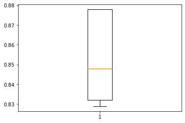

```python
scoring = "recall"
kfold = StratifiedKFold(
    n_splits=5, shuffle=True, random_state=1
)  # Setting number of splits equal to 5
cv_result_under = cross_val_score(
    estimator=log_reg_under, X=X_train_un, y=y_train_un, scoring=scoring, cv=kfold
)
# Plotting boxplots for CV scores of model defined above
plt.boxplot(cv_result_under)
plt.show()
```

```python
log_reg_under_train = model_performance_classification_sklearn(log_reg_under, X_train_un, y_train_un)
print("Training performance")
log_reg_under_train
```

```
Training performance
```

|  | Accuracy | Recall | Precision | F1 | Minimum_Vs_Model_cost |
| --- | --- | --- | --- | --- | --- |
| 0 | 0.862 | 0.856 | 0.867 | 0.861 | 0.779 |

```python
# Calculating different metrics on validation set
log_reg_under_val_perf = model_performance_classification_sklearn(
    log_reg_under, X_val, y_val
)
print("Validation performance:")
log_reg_under_val_perf
```

```
Validation performance:
```

|  | Accuracy | Recall | Precision | F1 | Minimum_Vs_Model_cost |
| --- | --- | --- | --- | --- | --- |
| 0 | 0.863 | 0.872 | 0.269 | 0.411 | 0.499 |

### Observation

This model is genralizing well but the Minimum_Vs_Model_cost is only 77%. Maybe not the model we need to get our solution. The validation of the model on Validation data is underfitting and Minimum_Vs_Model_cost is at 49%.